# tsiamy_final

$$\Large{\textbf{Question 1}}$$

At first we load the data of the 1st exercise from sheetname "Data1". Since subquestion a asks for one-way parametric anova for each of the continous variables Y,X1,X2,X3 against the categorical W, we are going to answer a one variable at a time.

```r
library(xlsx)
library(plyr)
library(dplyr)
library(ggplot2)
library(ggthemes)
library(gridExtra)
my_data<-as.data.frame(read.xlsx(file="C:/Users/alex/Desktop/!!/aueb/probability_and_statistics_for_data_analysis/hw/Assignment_3_Data.xlsx",
                                 sheetName = "Data1",header=TRUE))
head(my_data)
```

| Y | X1 | X2 | X3 | W |
| --- | --- | --- | --- | --- |
| 5.1 | 3.5 | 1.4 | 0.2 | A |
| 4.9 | 3.0 | 1.4 | 0.2 | A |
| 4.7 | 3.2 | 1.3 | 0.2 | A |
| 4.6 | 3.1 | 1.5 | 0.2 | A |
| 5.0 | 3.6 | 1.4 | 0.2 | A |
| 5.4 | 3.9 | 1.7 | 0.4 | A |

## Y~W

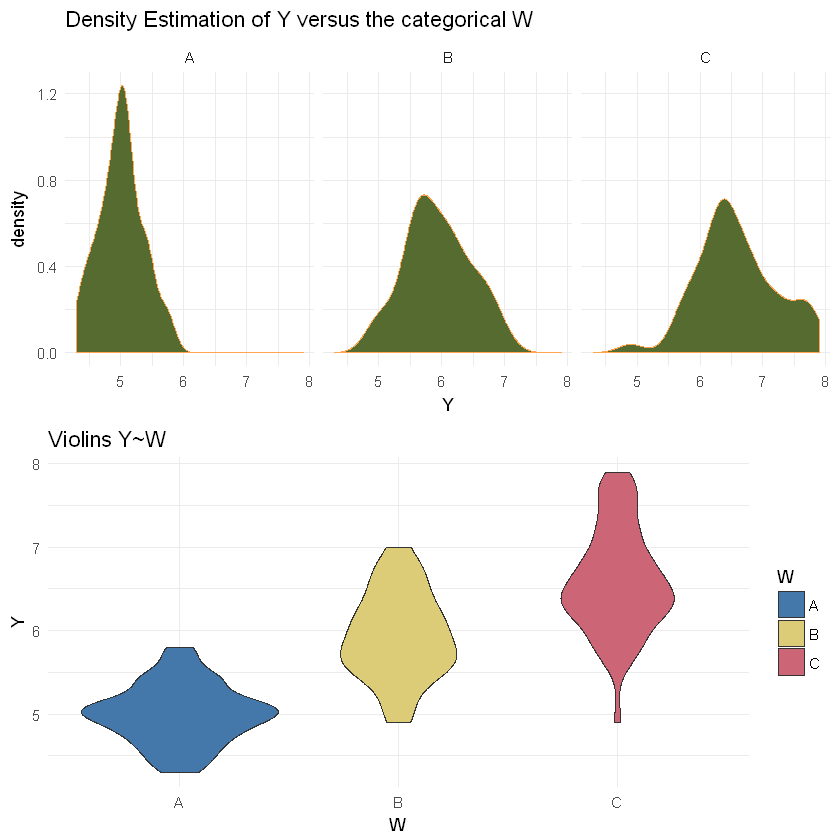

```r
p1<-ggplot(my_data,aes(Y))+
  geom_density(fill="darkolivegreen",colour="tan1")+
  theme_minimal()+
  facet_grid(~W)+
  ggtitle('Density Estimation of Y versus the categorical W')
p2<-ggplot(my_data,aes(W,Y))+
    geom_violin(aes(fill=W))+
    scale_fill_ptol()+
    theme_minimal()+
    ggtitle('Violins Y~W')
grid.arrange(p1,p2)
```

At first we need to obtain a graphical representation of the continous variable for the various levels of the categorical variable. Besides always being a good start to visualize our data, it can be a first step to check whether the sample distributions are close to normal (one of the assumptions of the ANOVA methodology). Apart from that, it is always beneficial to create a box plot to compare the differences of Y between the levels of W. Even better, we can turn the box plot to a violin plot.

```r
fit<-aov(Y~W,data=my_data)
summary(fit)
```

```
             Df Sum Sq Mean Sq F value Pr(>F)
W             2  63.21  31.606   119.3 <2e-16 ***
Residuals   147  38.96   0.265
---
Signif. codes:  0 '***' 0.001 '**' 0.01 '*' 0.05 '.' 0.1 ' ' 1
```

The analysis of variance indicates that we can reject the null hypothesis of the 3 means of Y for the 3 different levels of W being equal. However, we must first chech the assumption of analysis of variance, the normality of the samples and their common variance. The first assumption can equivalently be checked through the normality of the residuals of the fitted model.

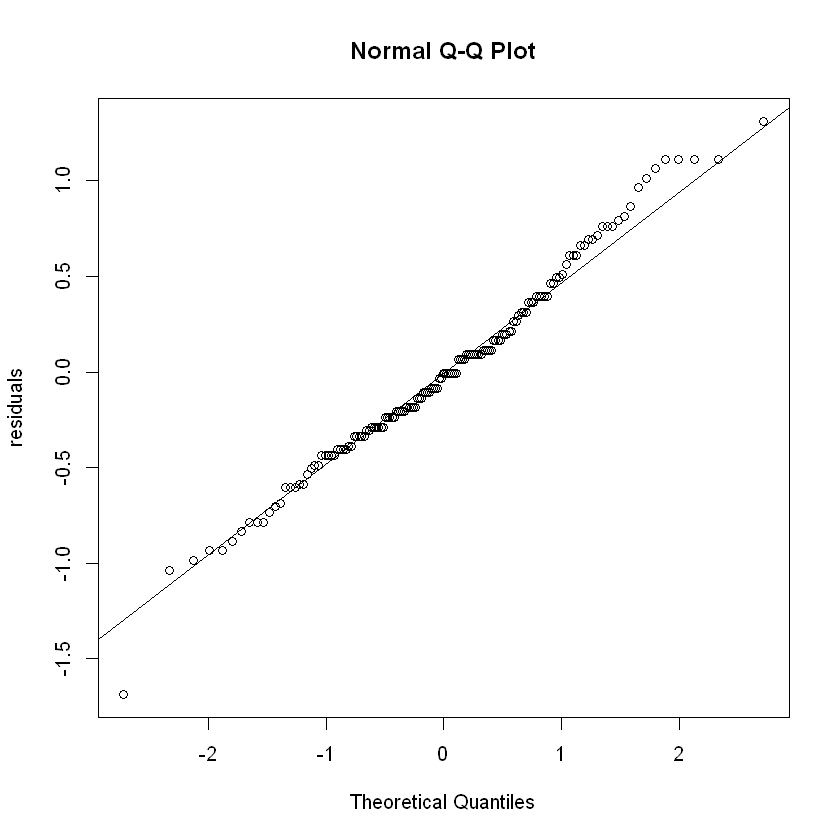

```r
qqnorm(fit$residuals,ylab='residuals')
qqline(fit$residuals)
```

```r
library(nortest)
shapiro.test(fit$residuals)
ad.test(fit$residuals)
lillie.test(fit$residuals)
```

```
	Shapiro-Wilk normality test

data:  fit$residuals
W = 0.9879, p-value = 0.2189
```

```
	Anderson-Darling normality test

data:  fit$residuals
A = 0.59794, p-value = 0.1188
```

```
	Lilliefors (Kolmogorov-Smirnov) normality test

data:  fit$residuals
D = 0.07331, p-value = 0.04711
```

As we can see, we are not entirely sure of the normality of the residuals, as the quantiles of the residuals in the right part deviate from the theoretical normal quantiles and one of the normality tests rejects the normality null hypothesis.

```r
bartlett.test(Y~W,data=my_data)
fligner.test(Y~W,data=my_data)
```

```
	Bartlett test of homogeneity of variances

data:  Y by W
Bartlett's K-squared = 16.006, df = 2, p-value = 0.0003345
```

```
	Fligner-Killeen test of homogeneity of variances

data:  Y by W
Fligner-Killeen:med chi-squared = 11.618, df = 2, p-value = 0.003
```

Both tests for homogeneity of variance can reject the null hypothesis, of the groups having the same variance. In combination with the results of the normality checks, it seems we should turn to non parametric ways of performing analysis of variance.

```r
kruskal.test(Y~W,data=my_data)
```

```
	Kruskal-Wallis rank sum test

data:  Y by W
Kruskal-Wallis chi-squared = 96.937, df = 2, p-value < 2.2e-16
```

The results of the non parametric analysis of variance indicate too that there is statistically significant difference between the means of the groups. So we have statistical significant indications that at least one of the means differs from the others. In order to find out about their specific differences, we are going to use Tukey's test and pairwise t-test.2

```r
pairwise.t.test(my_data$Y,my_data$W)
TukeyHSD(fit,conf.level = 0.95)
```

```
	Pairwise comparisons using t tests with pooled SD

data:  my_data$Y and my_data$W

  A       B
B 1.8e-15 -
C < 2e-16 2.8e-09

P value adjustment method: holm
```

```
  Tukey multiple comparisons of means
    95% family-wise confidence level

Fit: aov(formula = Y ~ W, data = my_data)

$W
     diff       lwr       upr p adj
B-A 0.930 0.6862273 1.1737727     0
C-A 1.582 1.3382273 1.8257727     0
C-B 0.652 0.4082273 0.8957727     0
```

The above tests indicate that there are differences between all of them.

### X1~W

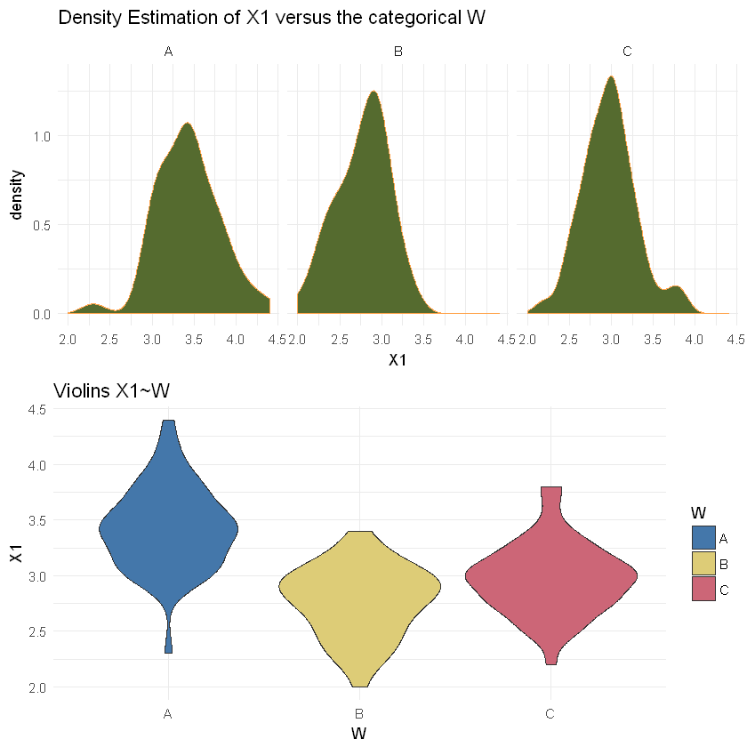

```r
p1<-ggplot(my_data,aes(X1))+
  geom_density(fill="darkolivegreen",colour="tan1")+
  theme_minimal()+
  facet_grid(~W)+
  ggtitle('Density Estimation of X1 versus the categorical W')
p2<-ggplot(my_data,aes(W,X1))+
    geom_violin(aes(fill=W))+
    scale_fill_ptol()+
    theme_minimal()+
    ggtitle('Violins X1~W')
grid.arrange(p1,p2)
```

```r
fit<-aov(X1~W,data=my_data)
summary(fit)
```

```
             Df Sum Sq Mean Sq F value Pr(>F)
W             2  11.35   5.672   49.16 <2e-16 ***
Residuals   147  16.96   0.115
---
Signif. codes:  0 '***' 0.001 '**' 0.01 '*' 0.05 '.' 0.1 ' ' 1
```

This time the densities are closer to normals and the violins indicate that we may have differences between the means of the groups, a conclusion that anova supports by rejecting the null hypothesis of equality.

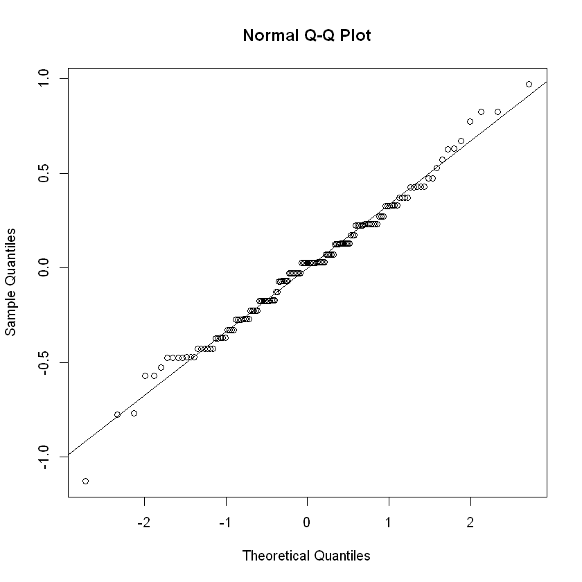

```r
qqnorm(fit$residuals)
qqline(fit$residuals)
```

```r
library(nortest)
shapiro.test(fit$residuals)
ad.test(fit$residuals)
lillie.test(fit$residuals)
```

```
	Shapiro-Wilk normality test

data:  fit$residuals
W = 0.98948, p-value = 0.323
```

```
	Anderson-Darling normality test

data:  fit$residuals
A = 0.49504, p-value = 0.2116
```

```
	Lilliefors (Kolmogorov-Smirnov) normality test

data:  fit$residuals
D = 0.064045, p-value = 0.1386
```

QQ-plot and normality tests indicate that we don't have enough evidence to reject the null hypothesis of normality.

```r
bartlett.test(X1~W,data=my_data)
fligner.test(X1~W,data=my_data)
```

```
	Bartlett test of homogeneity of variances

data:  X1 by W
Bartlett's K-squared = 2.0911, df = 2, p-value = 0.3515
```

```
	Fligner-Killeen test of homogeneity of variances

data:  X1 by W
Fligner-Killeen:med chi-squared = 0.9122, df = 2, p-value = 0.6338
```

We also lack the required evidence to reject homoscedasticity assumption. In this case, it seems that the assumptions of anova hold just fine.

```r
pairwise.t.test(my_data$X1,my_data$W)
TukeyHSD(fit,conf.level = 0.95)
```

```
	Pairwise comparisons using t tests with pooled SD

data:  my_data$X1 and my_data$W

  A       B
B < 2e-16 -
C 9.1e-10 0.0031

P value adjustment method: holm
```

```
  Tukey multiple comparisons of means
    95% family-wise confidence level

Fit: aov(formula = X1 ~ W, data = my_data)

$W
      diff         lwr        upr     p adj
B-A -0.658 -0.81885528 -0.4971447 0.0000000
C-A -0.454 -0.61485528 -0.2931447 0.0000000
C-B  0.204  0.04314472  0.3648553 0.0087802
```

The above tests indicate that there are differences between all combinations of group means. While the assumptions of anova hold fine, we did non-parametric anova to check if the results are the same. As the examination below indicates, non-parametric anova rejects too the assumption of equality.

```r
kruskal.test(X1~W,data=my_data)
```

```
	Kruskal-Wallis rank sum test

data:  X1 by W
Kruskal-Wallis chi-squared = 63.571, df = 2, p-value = 1.569e-14
```

### X2 ~W

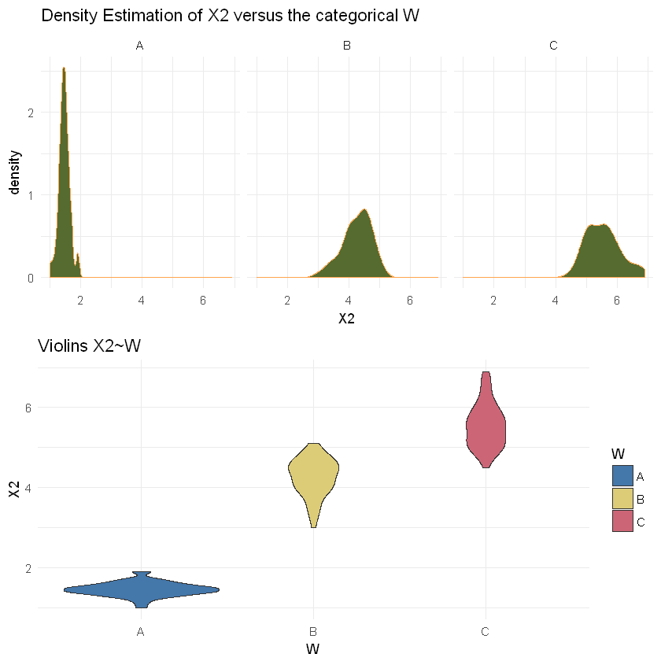

```r
p1<-ggplot(my_data,aes(X2))+
  geom_density(fill="darkolivegreen",colour="tan1")+
  theme_minimal()+
  facet_grid(~W)+
  ggtitle('Density Estimation of X2 versus the categorical W')
p2<-ggplot(my_data,aes(W,X2))+
    geom_violin(aes(fill=W))+
    scale_fill_ptol()+
    theme_minimal()+
    ggtitle('Violins X2~W')
grid.arrange(p1,p2)
```

```r
fit<-aov(X2~W,data=my_data)
summary(fit)
```

```
             Df Sum Sq Mean Sq F value Pr(>F)
W             2  437.1  218.55    1180 <2e-16 ***
Residuals   147   27.2    0.19
---
Signif. codes:  0 '***' 0.001 '**' 0.01 '*' 0.05 '.' 0.1 ' ' 1
```

In this case, anova rejects again the null hypothesis of equality, though as the above graphs indicate we can easily reject anova's hypotheses.

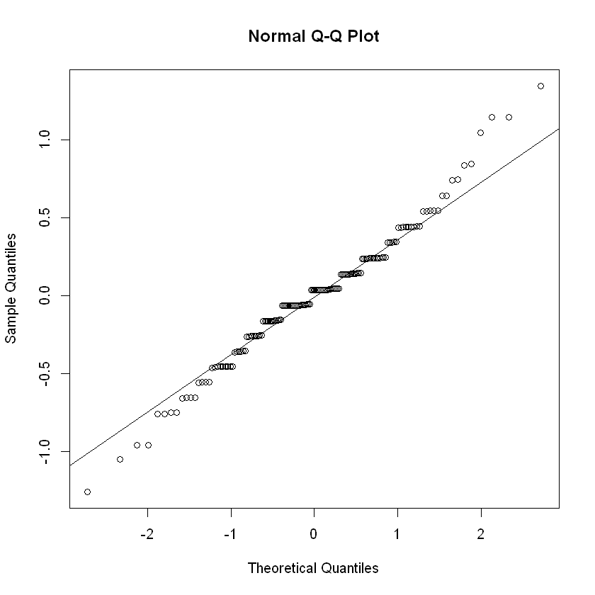

```r
qqnorm(fit$residuals)
qqline(fit$residuals)
```

```r
library(nortest)
shapiro.test(fit$residuals)
ad.test(fit$residuals)
lillie.test(fit$residuals)
```

```
	Shapiro-Wilk normality test

data:  fit$residuals
W = 0.98108, p-value = 0.03676
```

```
	Anderson-Darling normality test

data:  fit$residuals
A = 1.1061, p-value = 0.006537
```

```
	Lilliefors (Kolmogorov-Smirnov) normality test

data:  fit$residuals
D = 0.095669, p-value = 0.001876
```

Normality assumption is rejected by all tests. As the examinations below indicate, we can also reject the homoscedasticity assumption, se we turn to kruskal-wallis test to perform anova. This test also rejects the equality hypothesis. The last tests point out that we can spot differences between every combination of levels.

```r
bartlett.test(X2~W,data=my_data)
fligner.test(X2~W,data=my_data)
```

```
	Bartlett test of homogeneity of variances

data:  X2 by W
Bartlett's K-squared = 55.423, df = 2, p-value = 9.229e-13
```

```
	Fligner-Killeen test of homogeneity of variances

data:  X2 by W
Fligner-Killeen:med chi-squared = 34.708, df = 2, p-value = 2.906e-08
```

```r
kruskal.test(X2~W,data=my_data)
```

```
	Kruskal-Wallis rank sum test

data:  X2 by W
Kruskal-Wallis chi-squared = 130.41, df = 2, p-value < 2.2e-16
```

```r
pairwise.t.test(my_data$X2,my_data$W)
TukeyHSD(fit,conf.level = 0.95)
```

```
	Pairwise comparisons using t tests with pooled SD

data:  my_data$X2 and my_data$W

  A      B
B <2e-16 -
C <2e-16 <2e-16

P value adjustment method: holm
```

[output not shown]

### X3~W

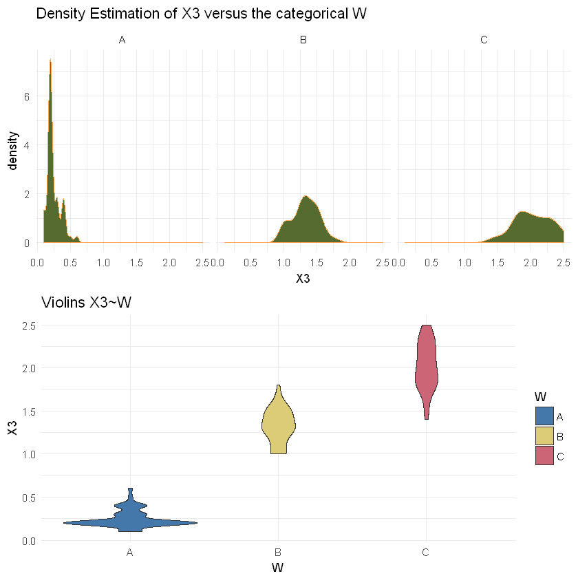

```r
p1<-ggplot(my_data,aes(X3))+
  geom_density(fill="darkolivegreen",colour="tan1")+
  theme_minimal()+
  facet_grid(~W)+
  ggtitle('Density Estimation of X3 versus the categorical W')
p2<-ggplot(my_data,aes(W,X3))+
    geom_violin(aes(fill=W))+
    scale_fill_ptol()+
    theme_minimal()+
    ggtitle('Violins X3~W')
grid.arrange(p1,p2)
```

```r
fit<-aov(X3~W,data=my_data)
summary(fit)
```

```
             Df Sum Sq Mean Sq F value Pr(>F)
W             2  80.41   40.21     960 <2e-16 ***
Residuals   147   6.16    0.04
---
Signif. codes:  0 '***' 0.001 '**' 0.01 '*' 0.05 '.' 0.1 ' ' 1
```

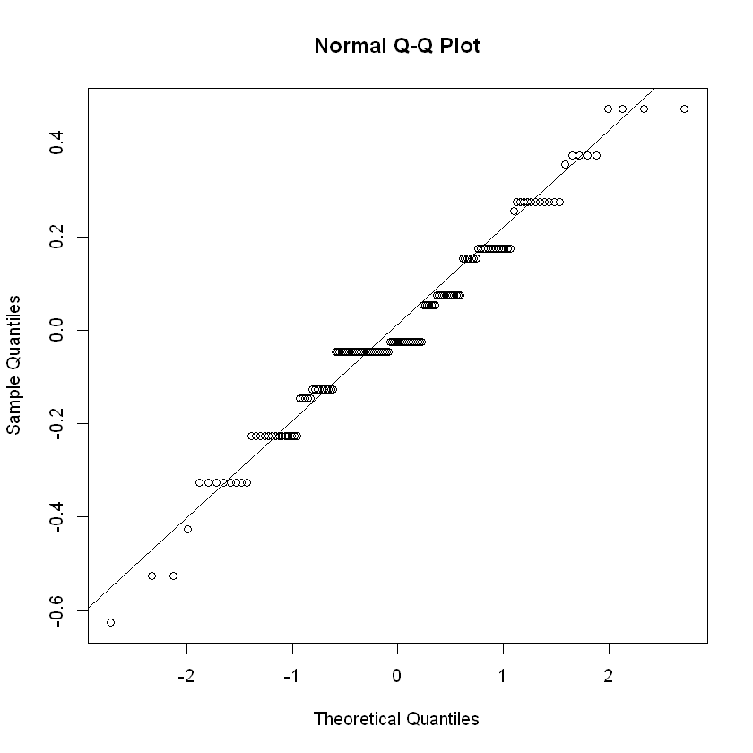

```r
qqnorm(fit$residuals)
qqline(fit$residuals)
```

```r
library(nortest)
shapiro.test(fit$residuals)
ad.test(fit$residuals)
lillie.test(fit$residuals)
```

```
	Shapiro-Wilk normality test

data:  fit$residuals
W = 0.97217, p-value = 0.003866
```

```
	Anderson-Darling normality test

data:  fit$residuals
A = 1.8447, p-value = 9.831e-05
```

```
	Lilliefors (Kolmogorov-Smirnov) normality test

data:  fit$residuals
D = 0.14422, p-value = 4.263e-08
```

```r
bartlett.test(X3~W,data=my_data)
fligner.test(X3~W,data=my_data)
```

```
	Bartlett test of homogeneity of variances

data:  X3 by W
Bartlett's K-squared = 39.213, df = 2, p-value = 3.055e-09
```

```
	Fligner-Killeen test of homogeneity of variances

data:  X3 by W
Fligner-Killeen:med chi-squared = 29.387, df = 2, p-value = 4.157e-07
```

```r
pairwise.t.test(my_data$X3,my_data$W)
TukeyHSD(fit,conf.level = 0.95)
```

```
	Pairwise comparisons using t tests with pooled SD

data:  my_data$X3 and my_data$W

  A      B
B <2e-16 -
C <2e-16 <2e-16

P value adjustment method: holm
```

```
  Tukey multiple comparisons of means
    95% family-wise confidence level

Fit: aov(formula = X3 ~ W, data = my_data)

$W
    diff       lwr       upr p adj
B-A 1.08 0.9830903 1.1769097     0
C-A 1.78 1.6830903 1.8769097     0
C-B 0.70 0.6030903 0.7969097     0
```

```r
kruskal.test(X2~W,data=my_data)
```

```
	Kruskal-Wallis rank sum test

data:  X2 by W
Kruskal-Wallis chi-squared = 130.41, df = 2, p-value < 2.2e-16
```

In order to provide a scatter-plot matrix for all variables, we are going to make use of the package GGally and its function ggpairs.

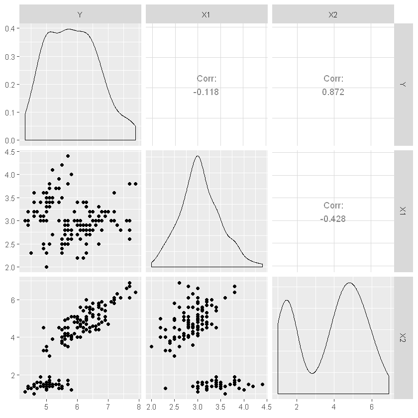

```r
library(GGally)
ggpairs(data=my_data,column=1:3,diag = list(continuous =
  "densityDiag"))
```

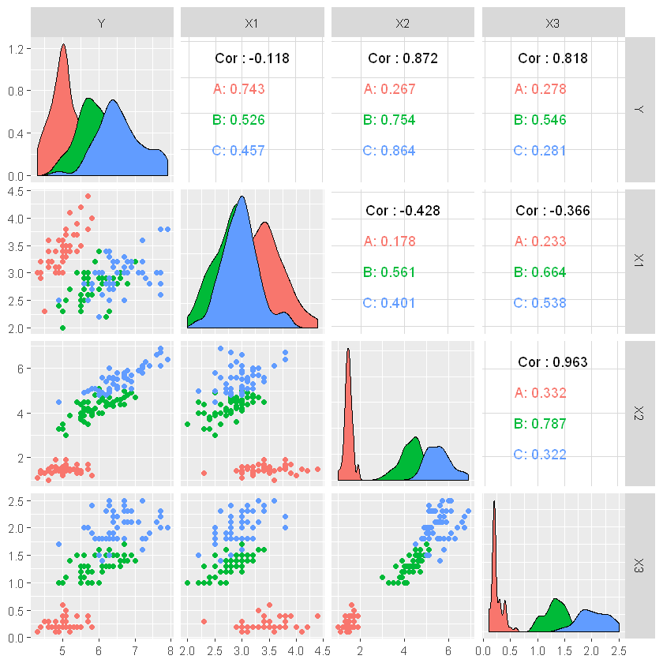

```r
library(GGally)
ggpairs(data=my_data,column=1:4,mapping=ggplot2::aes(colour = W), diag = list(continuous =
  "densityDiag"))
```

```r
model<-lm(Y~X1+X2+X3,data=my_data)
summary(model)
```

```
Call:
lm(formula = Y ~ X1 + X2 + X3, data = my_data)

Residuals:
     Min       1Q   Median       3Q      Max
-0.82816 -0.21989  0.01875  0.19709  0.84570

Coefficients:
            Estimate Std. Error t value Pr(>|t|)
(Intercept)  1.85600    0.25078   7.401 9.85e-12 ***
X1           0.65084    0.06665   9.765  < 2e-16 ***
X2           0.70913    0.05672  12.502  < 2e-16 ***
X3          -0.55648    0.12755  -4.363 2.41e-05 ***
---
Signif. codes:  0 '***' 0.001 '**' 0.01 '*' 0.05 '.' 0.1 ' ' 1

Residual standard error: 0.3145 on 146 degrees of freedom
Multiple R-squared:  0.8586,	Adjusted R-squared:  0.8557
F-statistic: 295.5 on 3 and 146 DF,  p-value: < 2.2e-16
```

The adjusted R-squared (quantity which indicates the fraction of Y's variance that is explained by the corresponding model) is large enough, all three explanatory variables seem to be statistically significant and F-test rejects the null hypothesis of all 3 explanatory variables being statistically insignificant. We also have to check the assumptions of the regression (linearity, normality of the residuals, homoscedasticity of the residuals and independence of $\textbf{X}$ and residuals.) The latter three assumptions are checked the same way we check them in simple linear regression. The linearity of multiple linear regression model can be proved that it can be equivalently be checked through the linearity between each of the explanatory variable and the corresponding partial residuals.

```r
residuals(model,"partial")
```

|  | X1 | X2 | X3 |
| --- | --- | --- | --- |
| 1 | 0.37268815 | -1.587549 | 0.64069591 |
| 2 | 0.17268815 | -1.462130 | 0.76611449 |
| 3 | 0.04360135 | -1.792298 | 0.50686025 |
| 4 | -0.19822504 | -1.827214 | 0.33011758 |
| 5 | 0.27268815 | -1.752633 | 0.47561219 |
| 6 | 0.57124510 | -1.436587 | 0.46762146 |
| 7 | -0.07166358 | -1.966817 | 0.20577963 |
| 8 | 0.20177496 | -1.622465 | 0.53486643 |
| 9 | -0.32731185 | -1.897047 | 0.33119821 |
| 10 | 0.04612669 | -1.582862 | 0.63011758 |
| 11 | 0.60177496 | -1.417716 | 0.73961528 |
| 12 | -0.06913824 | -1.822465 | 0.26395323 |
| 13 | 0.01703989 | -1.617779 | 0.66611449 |
| 14 | -0.27022052 | -2.117779 | 0.37885408 |
| 15 | 1.21451455 | -1.212968 | 1.15710372 |
| 16 | 1.01307149 | -1.462006 | 0.58402927 |
| 17 | 0.85489788 | -1.436587 | 0.75127424 |
| 18 | 0.42833642 | -1.531901 | 0.64069591 |
| 19 | 0.81559683 | -1.127152 | 0.83270517 |
| 20 | 0.35742322 | -1.727152 | 0.37453157 |
| 21 | 0.45994857 | -1.222465 | 0.79304004 |
| 22 | 0.41307149 | -1.606420 | 0.43961528 |
| 23 | 0.15634094 | -2.152633 | 0.35926498 |
| 24 | 0.32689336 | -1.290437 | 0.55812375 |
| 25 | -0.28187782 | -1.822465 | 0.05121365 |
| 26 | 0.13086176 | -1.362130 | 0.72428810 |
| 27 | 0.24215829 | -1.511169 | 0.46395323 |
| 28 | 0.40177496 | -1.487549 | 0.66978271 |
| 29 | 0.47268815 | -1.422465 | 0.80577963 |
| 30 | -0.16913824 | -1.792298 | 0.29412067 |
| ... | ... | ... | ... |
| 121 | 0.29203432 | 1.5763158 | -0.41332037 |
| 122 | -0.60760491 | 0.3697059 | -0.88567994 |
| 123 | 0.21595756 | 2.4697059 | -0.06211746 |
| 124 | -0.01890145 | 1.0234931 | -0.12059622 |
| 125 | -0.01926222 | 1.1999356 | -0.67840408 |
| 126 | 0.10105340 | 1.5980745 | -0.32605995 |
| 127 | -0.04798825 | 0.8584093 | -0.21476674 |
| 128 | -0.21890145 | 0.6282419 | -0.51584737 |
| 129 | -0.24834902 | 1.2253541 | -0.58207231 |
| 130 | 0.13158326 | 1.6169454 | -0.05406613 |
| 131 | 0.28578847 | 2.1140576 | 0.06336171 |
| 132 | 0.62869715 | 2.0188687 | -0.30021503 |
| 133 | -0.19270075 | 1.2810024 | -0.58207231 |
| 134 | -0.32767264 | 0.7914645 | -0.32750633 |
| 135 | -0.93788688 | 0.6659837 | -0.75190487 |
| 136 | 0.80838153 | 2.5064832 | 0.23319428 |
| 137 | -0.18140422 | 0.9017966 | -1.07257460 |
| 138 | -0.34438062 | 0.8631582 | -0.70641026 |
| 139 | -0.24798825 | 0.5282419 | -0.54493417 |
| 140 | 0.39347737 | 1.5301030 | -0.13549706 |
| 141 | 0.21859578 | 1.4970478 | -0.47732345 |
| 142 | 0.71751349 | 1.6413995 | 0.07724253 |
| 143 | -0.60507957 | 0.5791413 | -0.76242261 |
| 144 | 0.05020792 | 1.4763158 | -0.65514676 |
| 145 | 0.20333085 | 1.4225286 | -0.67840408 |
| 146 | 0.44660030 | 1.5064832 | -0.12858695 |
| 147 | -0.03416638 | 1.2093088 | -0.06134198 |
| 148 | 0.07965550 | 1.1395384 | -0.32858695 |
| 149 | -0.19522610 | 0.7461484 | -1.03074821 |
| 150 | -0.56072784 | 0.4282419 | -0.85767376 |

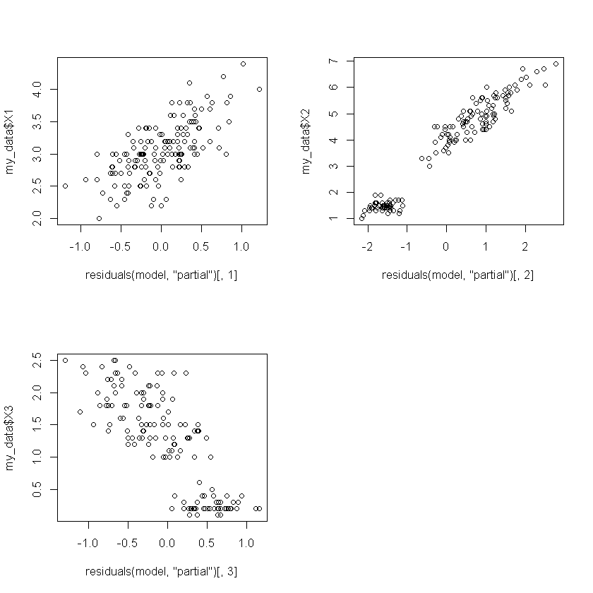

```r
par(mfrow=c(2,2))
plot(residuals(model,"partial")[,1],my_data$X1)
plot(residuals(model,"partial")[,2],my_data$X2)
plot(residuals(model,"partial")[,3],my_data$X3)
```

The above graph doesn't offer strong evidence against the linearity assumption. The 2nd graph offers some indications of problems because of the somewhat clustering in the left side, though the problem isn't large enough to consider the assumption rejected.

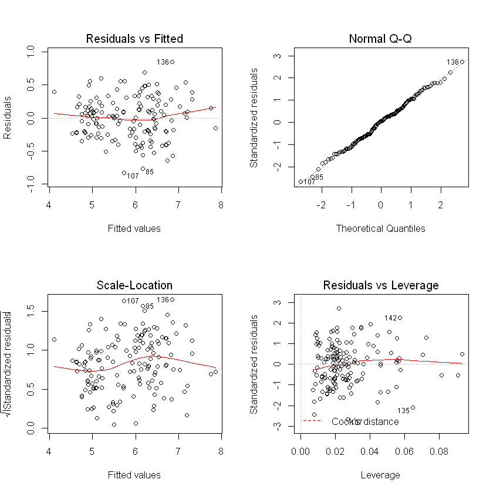

```r
par(mfrow=c(2,2))
plot(model)
```

The above graph indicates that there is not any distinguishable pattern in the change of residual's variance, the variance of the residuals seems constant and the assumption of normality of the residuals seems to hold just fine. Last but not least, seems that in this case we don't have any outliers or influential points.

```r
model<-lm(Y~1,data=my_data)
stepSR<-step(model, scope=list(lower = ~ 1, upper= ~ X1 + X2 + X3), direction="both", data=my_data)
```

```
Start:  AIC=-55.6
Y ~ 1

       Df Sum of Sq     RSS      AIC
+ X2    1    77.643  24.525 -267.641
+ X3    1    68.353  33.815 -219.460
+ X1    1     1.412 100.756  -55.690
<none>              102.168  -55.602

Step:  AIC=-267.64
Y ~ X2

       Df Sum of Sq     RSS     AIC
+ X1    1     8.196  16.329 -326.66
+ X3    1     0.644  23.881 -269.63
<none>               24.525 -267.64
- X2    1    77.643 102.168  -55.60

Step:  AIC=-326.66
Y ~ X2 + X1

       Df Sum of Sq     RSS     AIC
+ X3    1     1.883  14.445 -343.04
<none>               16.329 -326.66
- X1    1     8.196  24.525 -267.64
- X2    1    84.427 100.756  -55.69

Step:  AIC=-343.04
Y ~ X2 + X1 + X3

       Df Sum of Sq    RSS     AIC
<none>              14.445 -343.04
- X3    1    1.8834 16.329 -326.66
- X1    1    9.4353 23.881 -269.63
- X2    1   15.4657 29.911 -235.86
```

```r
stepSR$anova
```

| Step | Df | Deviance | Resid. Df | Resid. Dev | AIC |
| --- | --- | --- | --- | --- | --- |
|  | NA | NA | 149 | 102.16833 | -55.60203 |
| + X2 | -1 | 77.643300 | 148 | 24.52503 | -267.64114 |
| + X1 | -1 | 8.196270 | 147 | 16.32876 | -326.65606 |
| + X3 | -1 | 1.883359 | 146 | 14.44540 | -343.03884 |

While we are not able to talk about statistical significance, we can conclude from the above stepwise regression using AIC criterion that the full model X1+X2+X3 is the best to describe the response variable. In the same way, all subset approach we conduct below ends up in the same results about full model being the best to describe response variable.

```r
library(leaps)
leaps<-regsubsets(Y ~ X1+X2+X3,data=my_data, nbest=1)
summary(leaps)
```

```
Subset selection object
Call: regsubsets.formula(Y ~ X1 + X2 + X3, data = my_data, nbest = 1)
3 Variables  (and intercept)
   Forced in Forced out
X1     FALSE      FALSE
X2     FALSE      FALSE
X3     FALSE      FALSE
1 subsets of each size up to 3
Selection Algorithm: exhaustive
         X1  X2  X3
1  ( 1 ) " " "*" " "
2  ( 1 ) "*" "*" " "
3  ( 1 ) "*" "*" "*"
```

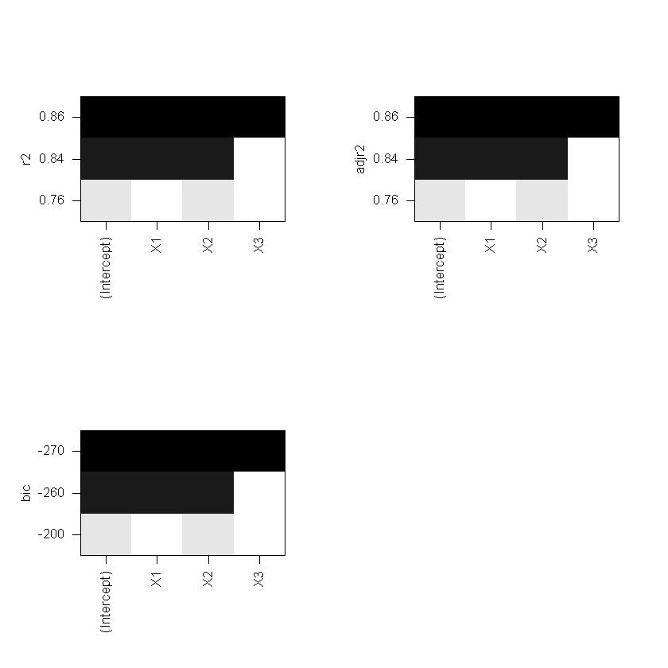

```r
par(mfrow=c(2,2))
plot(leaps,scale='r2')
plot(leaps,scale='adjr2')
plot(leaps,scale='bic')
```

```r
predict(lm(Y~X1+X2+X3,data=my_data),list(X1=3.1,X2=3.75,X3=1.2),int="c")
```

|  | fit | lwr | upr |
| --- | --- | --- | --- |
| 1 | 5.865058 | 5.814012 | 5.916104 |

So in the prediction above, the point estimate is 5.865058 and the lwr and upr values are the lower and upper values of the 95% confidence level.

$$\Large{\textbf{Question 2}}$$

```r
library(xlsx)
library(ggplot2)
library(ggthemes)
my_data<-as.data.frame(read.xlsx(file="C:/Users/alex/Desktop/!!/aueb/probability_and_statistics_for_data_analysis/hw/Assignment_3_Data.xlsx",
                                 sheetName = "Data2",header=TRUE))
head(my_data)
```

| Y | W | Z |
| --- | --- | --- |
| 16.0 | A | L |
| 30.4 | A | L |
| 34.8 | A | L |
| 37.2 | A | L |
| 35.3 | A | L |
| 39.2 | A | L |

Since we need to plot a continuous variable, we frequently want to plot a histogram or a kernel estimated density. To give this kind of presentation versus two categorical variables, we can just present the density of the continuous for each combination of values of the categorical variables.

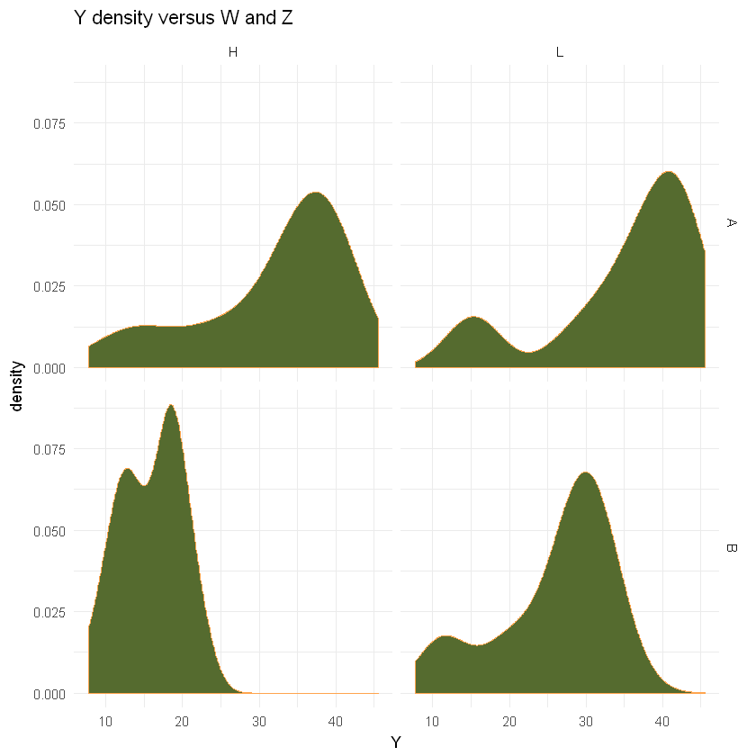

```r
library(ggplot2)
ggplot(my_data,aes(Y))+
    geom_density(fill="darkolivegreen",colour="tan1")+
    theme_minimal()+
    facet_grid(W~Z)+
    ggtitle('Y density versus W and Z')
```

Since we are going to perform two-way anova, a useful observation would be that the groups doesn't seem normal at all. As the point of the question is a bit different, we are going to let this observation aside for now.

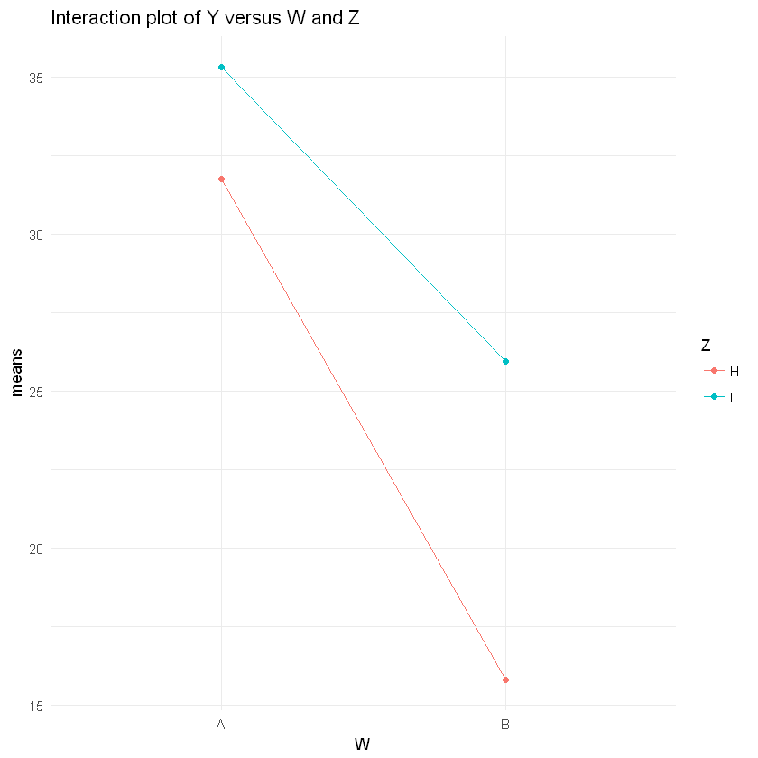

```r
library(plyr)
inter_plot_data<-ddply(my_data,~ W+Z ,summarise,means=mean(Y))
ggplot(inter_plot_data,aes(x=W,y=means,color=Z,group=Z))+
    geom_point()+
    geom_line()+
    theme_minimal()+
    ggtitle('Interaction plot of Y versus W and Z')
```

As the lines of the above graph are not parallel, we can detect interaction between variables W and Z.

```r
fit<-aov(Y~W*Z,data=my_data)
summary(fit)
```

```
            Df Sum Sq Mean Sq F value   Pr(>F)
W            1   3366    3366  52.509 2.38e-10 ***
Z            1    988     988  15.416 0.000182 ***
W:Z          1    226     226   3.522 0.064213 .
Residuals   80   5128      64
---
Signif. codes:  0 '***' 0.001 '**' 0.01 '*' 0.05 '.' 0.1 ' ' 1
```

The two-way analysis of variance indicates that both factors W,Z are statistically significant, meaning that different values of them affect the mean of Y in a statistically significant way. On the other hand, the interaction term is statistically insignificant.

Now in order to examine the assumptions of the two-way anova (normality of sample, homoscedasticity and independence within and between categoricals), we start with the normality assumption which we already kind of rejected graphically. This assumption can be examined by separating the 4 groups and checking their normality one by one or we could also check the normality of the residuals of the model. We choose to present both ways, just for the fun of it.

```r
library(nortest)
group1<-my_data[my_data$W=='A'& my_data$Z=='L',1]
group2<-my_data[my_data$W=='A'& my_data$Z=='H',1]
group3<-my_data[my_data$W=='B'& my_data$Z=='L',1]
group4<-my_data[my_data$W=='B'& my_data$Z=='H',1]
#1st group
ad.test(group1)
lillie.test(group1)
#2nd group
ad.test(group2)
lillie.test(group2)
#3rd group
ad.test(group3)
lillie.test(group3)
#4th group
ad.test(group4)
lillie.test(group4)
```

```
	Anderson-Darling normality test

data:  group1
A = 1.3857, p-value = 0.001006
```

```
	Lilliefors (Kolmogorov-Smirnov) normality test

data:  group1
D = 0.19213, p-value = 0.04167
```

```
	Anderson-Darling normality test

data:  group2
A = 1.2345, p-value = 0.002452
```

```
	Lilliefors (Kolmogorov-Smirnov) normality test

data:  group2
D = 0.21118, p-value = 0.01528
```

```
	Anderson-Darling normality test

data:  group3
A = 1.2209, p-value = 0.002656
```

```
	Lilliefors (Kolmogorov-Smirnov) normality test

data:  group3
D = 0.2176, p-value = 0.0106
```

```
	Anderson-Darling normality test

data:  group4
A = 0.51103, p-value = 0.174
```

```
	Lilliefors (Kolmogorov-Smirnov) normality test

data:  group4
D = 0.22013, p-value = 0.009147
```

As we can see, there are cases where we can reject with ease the normality assumptions of a group. The Q-Q plot below can offer the same answer of rejecting the normality assumption of the groups.

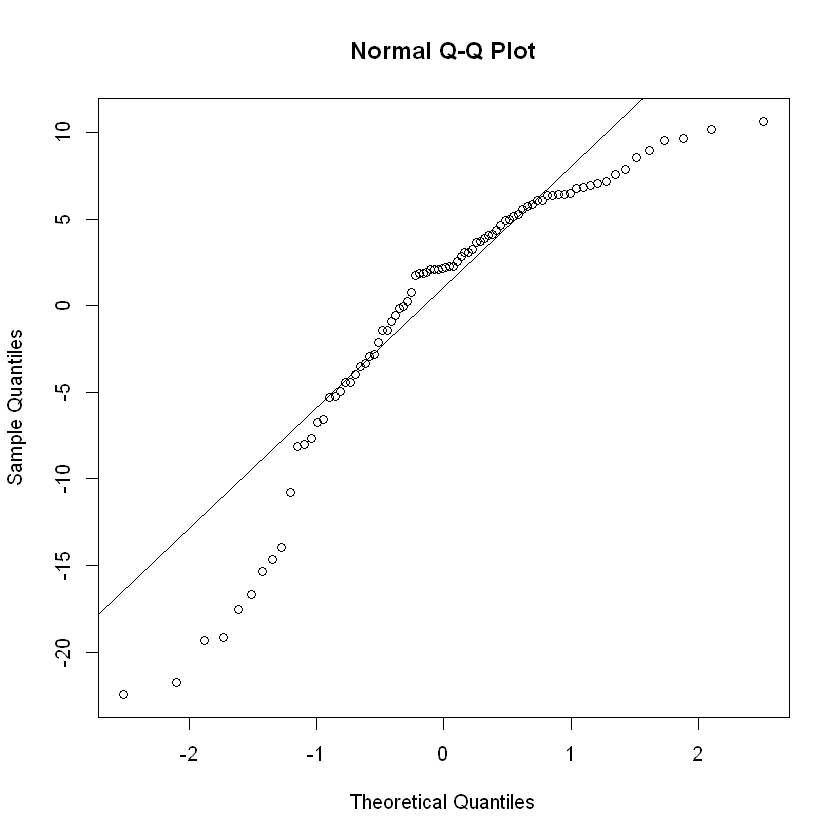

```r
qqnorm(fit$residuals)
qqline(fit$residuals)
```

We don't have to check homoscedasticity of the samples since one of the assumptions is violated, however we will show this assumption rejection too. We are going to use var.test to check the equality of the variances, since classical homoscedasticity tests we use in the one-way anova case don't work here.

```r
var(group1);var(group2);var(group3);var(group4)
var.test(group1,group2)
var.test(group1,group4)
```

92.0903333333333

93.022619047619

54.7916190476191

16.4752857142857

```
	F test to compare two variances

data:  group1 and group2
F = 0.98998, num df = 20, denom df = 20, p-value = 0.9823
alternative hypothesis: true ratio of variances is not equal to 1
95 percent confidence interval:
 0.4016978 2.4397849
sample estimates:
ratio of variances
         0.9899779
```

```
	F test to compare two variances

data:  group1 and group4
F = 5.5896, num df = 20, denom df = 20, p-value = 0.0003172
alternative hypothesis: true ratio of variances is not equal to 1
95 percent confidence interval:
  2.268063 13.775493
sample estimates:
ratio of variances
          5.589605
```

We can easily observe that there are combinations that can be declared equal and some others that are really far from it. So we can say that the assumption of homoscedasticity can be rejected too.

$$\Large{\textbf{Question 3}}$$

```r
library(xlsx)
library(ggplot2)
library(ggthemes)
my_data<-as.data.frame(read.xlsx(file="C:/Users/alex/Desktop/!!/aueb/probability_and_statistics_for_data_analysis/hw/Assignment_3_Data.xlsx",
                                 sheetName = "Data3",header=TRUE))
head(my_data)
```

| Y | T | D |
| --- | --- | --- |
| 42 | 0 | A |
| 51 | 2 | A |
| 59 | 4 | A |
| 64 | 6 | A |
| 76 | 8 | A |
| 93 | 10 | A |

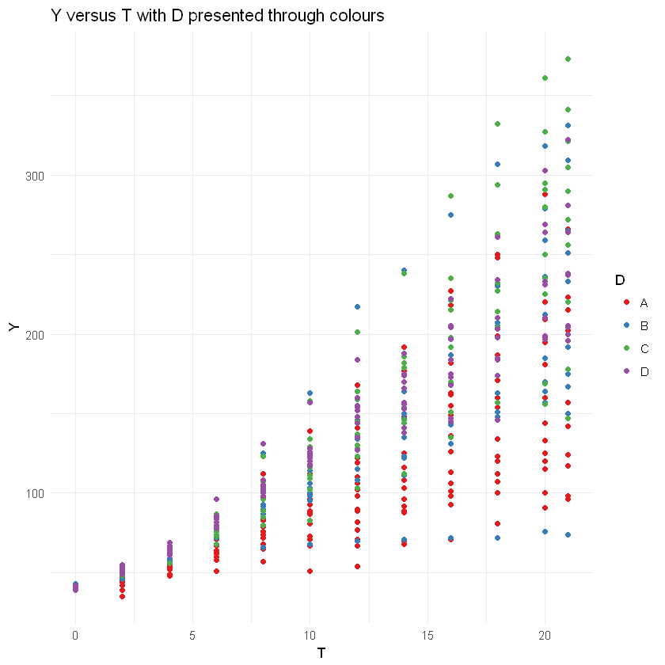

```r
ggplot(my_data,aes(x=T,y=Y,colour=D))+
    geom_point()+
    theme_minimal()+
    scale_colour_brewer(palette='Set1')+
    ggtitle('Y versus T with D presented through colours')
```

```r
model1<-lm(Y~T,data=my_data[my_data$D=='A',])
summary(model1)
model2<-lm(Y~T,data=my_data[my_data$D=='B',])
summary(model2)
model3<-lm(Y~T,data=my_data[my_data$D=='C',])
summary(model3)
model4<-lm(Y~T,data=my_data[my_data$D=='D',])
summary(model4)
```

```
Call:
lm(formula = Y ~ T, data = my_data[my_data$D == "A", ])

Residuals:
    Min      1Q  Median      3Q     Max
-78.609 -15.677  -0.324  11.069 130.391

Coefficients:
            Estimate Std. Error t value Pr(>|t|)
(Intercept)  30.9310     4.0948   7.554 1.15e-12 ***
T             6.8418     0.3286  20.822  < 2e-16 ***
---
Signif. codes:  0 '***' 0.001 '**' 0.01 '*' 0.05 '.' 0.1 ' ' 1

Residual standard error: 32.85 on 218 degrees of freedom
Multiple R-squared:  0.6654,	Adjusted R-squared:  0.6639
F-statistic: 433.5 on 1 and 218 DF,  p-value: < 2.2e-16
```

```
Call:
lm(formula = Y ~ T, data = my_data[my_data$D == "B", ])

Residuals:
     Min       1Q   Median       3Q      Max
-135.425  -16.780   -2.116   11.616  123.402

Coefficients:
            Estimate Std. Error t value Pr(>|t|)
(Intercept)  28.6336     7.1597   3.999 0.000111 ***
T             8.6091     0.5572  15.449  < 2e-16 ***
---
Signif. codes:  0 '***' 0.001 '**' 0.01 '*' 0.05 '.' 0.1 ' ' 1

Residual standard error: 41.36 on 118 degrees of freedom
Multiple R-squared:  0.6692,	Adjusted R-squared:  0.6664
F-statistic: 238.7 on 1 and 118 DF,  p-value: < 2.2e-16
```

```
Call:
lm(formula = Y ~ T, data = my_data[my_data$D == "C", ])

Residuals:
     Min       1Q   Median       3Q      Max
-111.131  -19.056   -1.865   15.484  114.869

Coefficients:
            Estimate Std. Error t value Pr(>|t|)
(Intercept)   18.250      6.617   2.758  0.00674 **
T             11.423      0.515  22.181  < 2e-16 ***
---
Signif. codes:  0 '***' 0.001 '**' 0.01 '*' 0.05 '.' 0.1 ' ' 1

Residual standard error: 38.22 on 118 degrees of freedom
Multiple R-squared:  0.8066,	Adjusted R-squared:  0.8049
F-statistic:   492 on 1 and 118 DF,  p-value: < 2.2e-16
```

```
Call:
lm(formula = Y ~ T, data = my_data[my_data$D == "D", ])

Residuals:
    Min      1Q  Median      3Q     Max
-59.651  -8.971  -2.650   7.849  87.206

Coefficients:
            Estimate Std. Error t value Pr(>|t|)
(Intercept)  30.7921     3.6817   8.363 1.55e-13 ***
T             9.7144     0.2904  33.454  < 2e-16 ***
---
Signif. codes:  0 '***' 0.001 '**' 0.01 '*' 0.05 '.' 0.1 ' ' 1

Residual standard error: 21.18 on 116 degrees of freedom
Multiple R-squared:  0.9061,	Adjusted R-squared:  0.9053
F-statistic:  1119 on 1 and 116 DF,  p-value: < 2.2e-16
```

Above we created 4 regression models, one for each level of the categorical D. We can easily observe that for each model, we have statistical significance for intercept and the effect of the T, though of course the significance as well as the adjusted-R squared is different in each of them. Now in order to examine the assumptions of each model, we are going to start with the linearity assumption between the explanatory and the response variable.

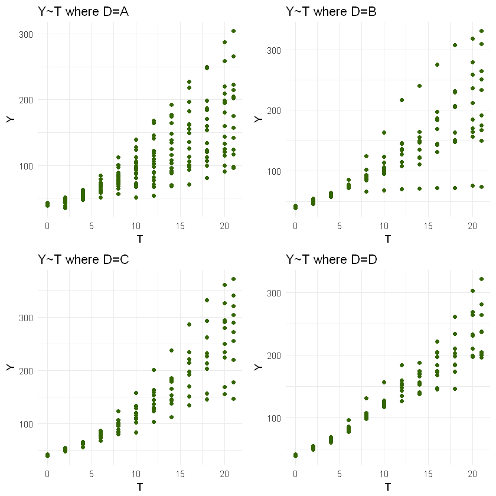

```r
library(plyr)
library(dplyr)
library(gridExtra)
aux<-filter(my_data,D=='A')
p1<-ggplot(aux,aes(x=T,y=Y))+
    geom_point(colour='#336600')+
    theme_minimal()+
    ggtitle('Y~T where D=A')
aux<-filter(my_data,D=='B')
p2<-ggplot(aux,aes(x=T,y=Y))+
    geom_point(colour='#336600')+
    theme_minimal()+
    ggtitle('Y~T where D=B')
aux<-filter(my_data,D=='C')
p3<-ggplot(aux,aes(x=T,y=Y))+
    geom_point(colour='#336600')+
    theme_minimal()+
    ggtitle('Y~T where D=C')
aux<-filter(my_data,D=='D')
p4<-ggplot(aux,aes(x=T,y=Y))+
    geom_point(colour='#336600')+
    theme_minimal()+
    ggtitle('Y~T where D=D')
grid.arrange(p1,p2,p3,p4,ncol=2)
```

The above plots indicate that the linearity assumption could hold , especially in the last 2 cases. In the first case, it seems that the variance is growing as T grows. In the second case, while there is a linear pattern from T=0 until T=8, we can observe a weird spread pattern from that point on, while there is also a group of points that continue the linear trend. In any case, as we will see below the simple model we chose for each case violates the assumptions. The first alternative we have in this case, is non-parametric way of regression, also known as Nadaraya-Watson estimation. We won't take this path since it's outside the scope of this course. The other way of dribbling the problem is try to fit different transformations like square root, log, log(log), powers of the variables and exponentials. After trying a lot of these, we concluded that none of them is good enough, so we end up in just showing the way we reject the basic models. The first graph below depicts a number of transformations we tried, though in these cases too the assumptions were violated (their assumption examination is skipped).

```
Warning message:
"Removed 10 rows containing non-finite values (stat_smooth)."`geom_smooth()` using method = 'loess'
```

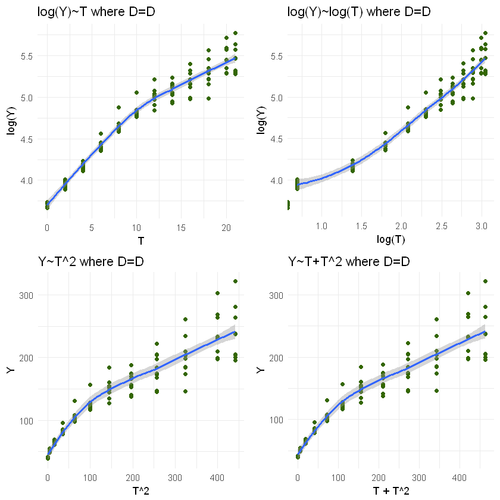

```r
aux<-filter(my_data,D=='D')
p1<-ggplot(aux,aes(x=T,y=log(Y)))+
    geom_point(colour='#336600')+
    theme_minimal()+
    geom_smooth()+
    ggtitle('log(Y)~T where D=D')
p2<-ggplot(aux,aes(x=log(T),y=log(Y)))+
    geom_point(colour='#336600')+
    theme_minimal()+
    geom_smooth()+
    ggtitle('log(Y)~log(T) where D=D')
p3<-ggplot(aux,aes(x=T^2,y=Y))+
    geom_point(colour='#336600')+
    theme_minimal()+
    geom_smooth()+
    ggtitle('Y~T^2 where D=D')
p4<-ggplot(aux,aes(x=T+T^2,y=Y))+
    geom_point(colour='#336600')+
    theme_minimal()+
    geom_smooth()+
    ggtitle('Y~T+T^2 where D=D')
grid.arrange(p1,p2,p3,p4,ncol=2)
```

## Model 1

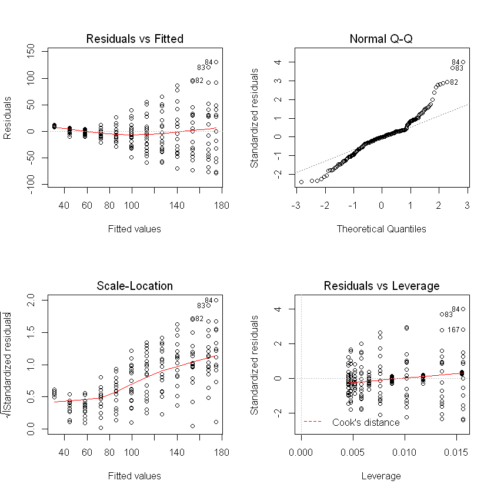

```r
par(mfrow=c(2,2))
plot(model1)
```

In this model we can deduct that variance of residuals is not constant (homoscedasticity rejected) and QQ-plot indicates against normality of residuals assumption.

## Model 2

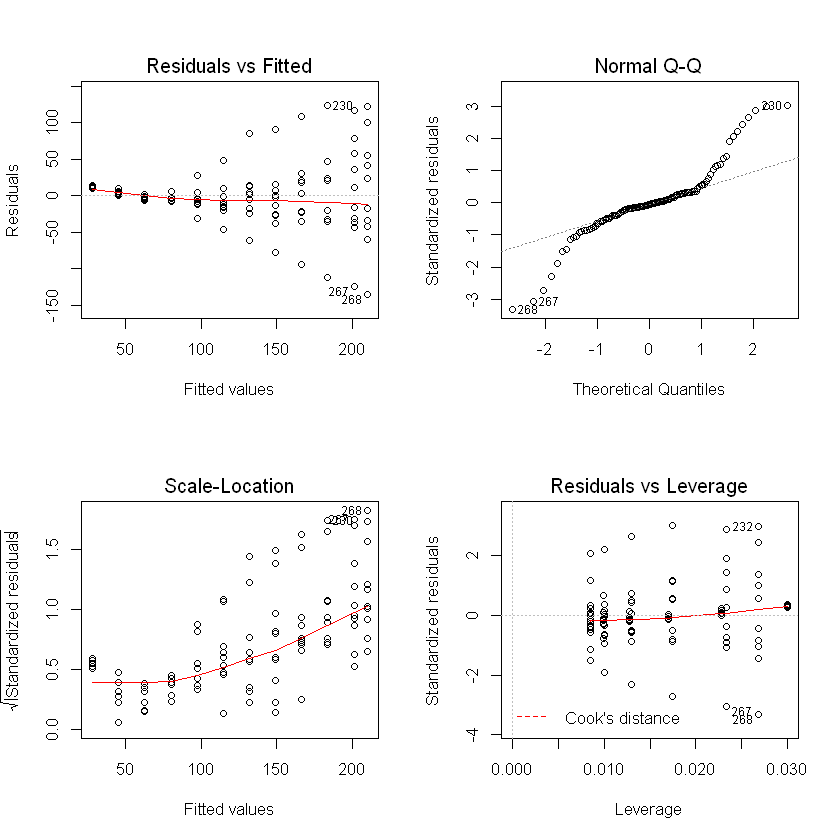

```r
par(mfrow=c(2,2))
plot(model2)
```

Normality of residuals is rejected here too and we can also see a clear pattern in the spread of residuals so homoscedasticity is rejected too.

## Model 3

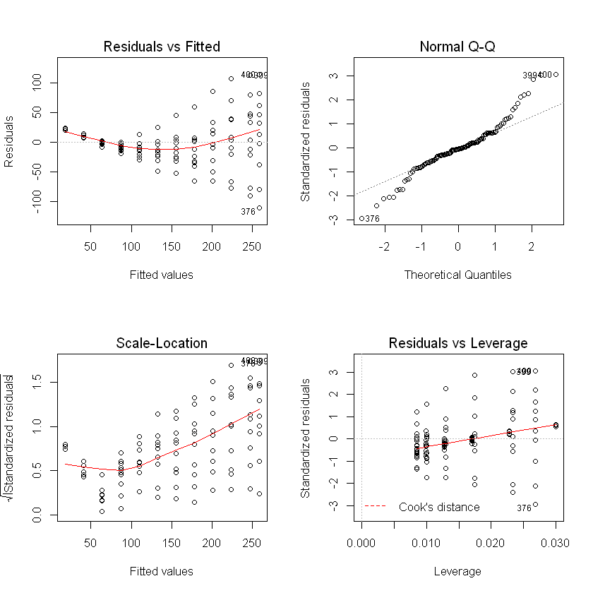

```r
par(mfrow=c(2,2))
plot(model3)
```

The same problems appear here too. Normality of residuals can be easily rejected and the first graph doesn't demonstrate a cloud of points (homoscedasticity is rejected here too).

## Model 4

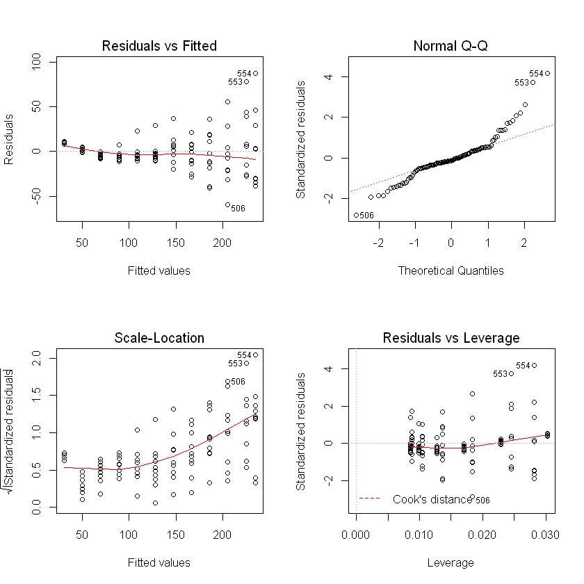

```r
par(mfrow=c(2,2))
plot(model4)
```